# SMALL WORLDS & PREFERENTIAL ATTACHMENT

SNA Week 9

Matt **Pietryka

# Overlaying networks on geographic maps: When you already have location data

The data we will use here is posted on Blackboard. It contains US airports and flights among them

```r
flights <- read.csv("Data/Dataset3-Airlines-EDGES.csv", header=TRUE, as.is=TRUE)
head(flights)
```

```
##   Source Target Freq
## 1      0    109   10
## 2      1     36   10
## 3      1     61   10
## 4      2    152   10
## 5      3    104   10
## 6      4    132   10
```

The airport file includes geographic coordinates - latitude and longitude. If your data lack coordinates, use the `geocode()` function from package `ggmap` to grab latitude and longitude for an address

```r
airports <- read.csv("Data/Dataset3-Airlines-NODES.csv", header=TRUE)
head(airports)
```

```
##   ID                     Label Code             City latitude  longitude
## 1  0       Adams Field Airport  LIT  Little Rock, AR 34.72944  -92.22444
## 2  1     Akron/canton Regional  CAK Akron/Canton, OH 40.91611  -81.44222
## 3  2      Albany International  ALB           Albany 42.73333  -73.80000
## 4  3                 Albemarle  CHO  Charlottesville 38.13333  -78.45000
## 5  4 Albuquerque International  ABQ      Albuquerque 35.04028 -106.60917
## 6  5  Alexandria International  AEX   Alexandria, LA 31.32750  -92.54861
##   ToFly Visits
## 1     0    105
## 2     0    123
## 3     0    129
## 4     1    114
## 5     0    105
## 6     0     93
```

Select only large airports: ones with more than 10 connections in the data.

```r
tab <- table(flights$Source)
big.id <- names(tab)[tab>10]
airports <- airports[airports$ID %in% big.id,]
flights  <- flights[flights$Source %in% big.id &
                    flights$Target %in% big.id, ]
```

In order to generate our plot, we will first add a map of the United states:

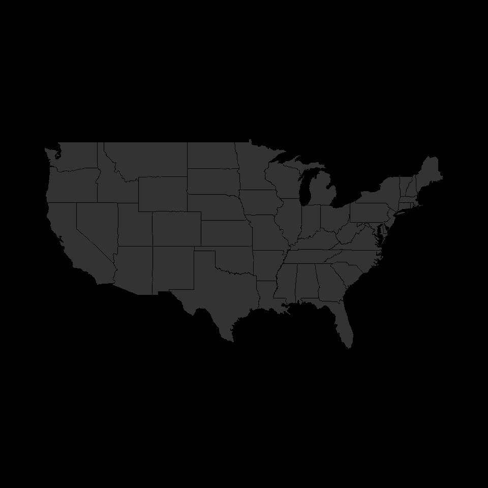

```r
# Plot a map of the united states:
map("state",
  col = "grey20",
  fill = TRUE,
  bg = "black",
  lwd = 0.1
)
```

Then we will add a point on the map for each airport:

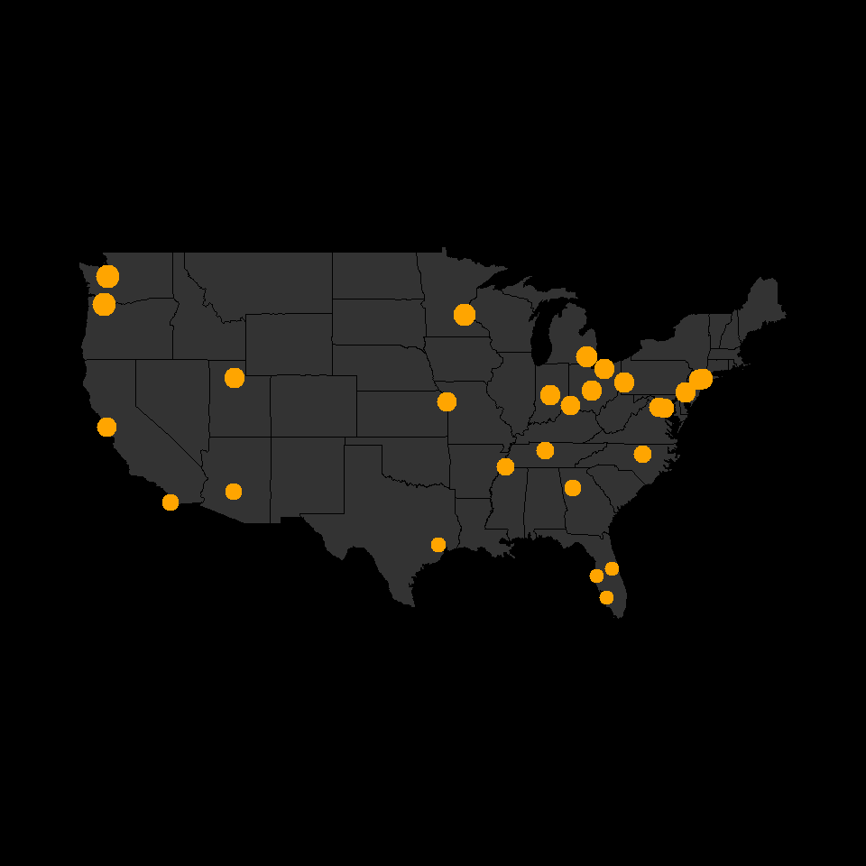

```r
# Plot a map of the united states:
map("state",
  col = "grey20",
  fill = TRUE,
  bg = "black",
  lwd = 0.1
)

# Add a point for each airport:
points(
  x = airports$longitude,
  y = airports$latitude,
  pch = 19,
  cex = airports$Visits / 80,
  col = "orange"
)
```

Next we will generate a color gradient to use for the edges in the network. Heavier edges will be lighter in color.

```r
col.1 <- adjustcolor("orange red", alpha=0.4)
col.2 <- adjustcolor("orange", alpha=0.4)
edge.pal <- colorRampPalette(c(col.1, col.2), alpha = TRUE)
edge.col <- edge.pal(100)
```

For each flight, use `gcIntermediate()` to generate the coordinates of the shortest arc that connects its start and end point. Then, we plot each arc using `lines()`.

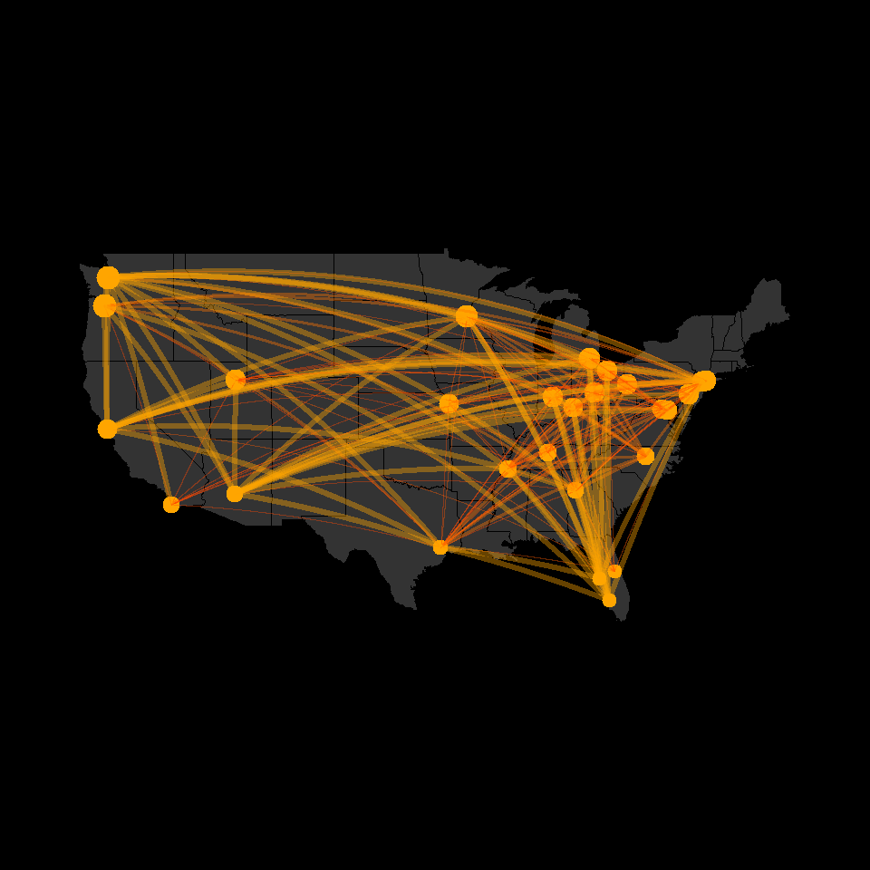

```r
for(i in 1:nrow(flights))  {
  node1 <- airports[airports$ID == flights[i,]$Source,]
  node2 <- airports[airports$ID == flights[i,]$Target,]

  arc <- gcIntermediate(
  c(node1[1, ]$longitude,
  node1[1, ]$latitude),
  c(node2[1, ]$longitude,
  node2[1, ]$latitude),
  n = 1000,
  addStartEnd = TRUE
  )
  edge.ind <- round(100 * flights[i, ]$Freq / max(flights$Freq))

  lines(arc, col = edge.col[edge.ind], lwd = edge.ind / 30)
}
```

# Overlaying networks on geographic maps: When you lack location data

To **find spatial data**, `ggmap::geocode` is your best friend:

```r
library(ggmap)

geocode("fl", "latlona")
```

```
##         lon      lat      address
## 1 -81.51575 27.66483 florida, usa
```

```r
geocode("florida", "latlona")
```

```
##         lon      lat      address
## 1 -81.51575 27.66483 florida, usa
```

```r
geocode("flor", "latlona")
```

```
##         lon      lat                                address
## 1 -117.1956 33.27165 vía de la flor, bonsall, ca 92003, usa
```

```r
geocode("flo state", "latlona")
```

```
##         lon      lat
## 1 -118.3618 34.09055
##                                                  address
## 1 7904 california route 2, west hollywood, ca 90046, usa
```

```r
geocode("flo state uni", "latlona")
```

```
##         lon      lat                                       address
## 1 -84.29849 30.44188 600 w college ave, tallahassee, fl 32306, usa
```

# Load the ‘firms_raw’, ‘edge_list’ & ‘node_data’ objects

We’ll be working with Quintin’s Firm data again.

The `Firms.RData` file is in the data folder on Blackboard. Note that these data are only a subset of the full dataset

```r
load("Data/Firms.RData")
```

# Construct the network

```r
# CREATE IGRAPH NETWORK
firmstate_net <- graph_from_data_frame(d = edge_list,
                                   vertices = node_data,
                                   directed = FALSE)

# ONE MODE PROJECTION
states_net <- bipartite_projection(firmstate_net)$proj2

# SOCIOMATRIX
states_socio <- get.adjacency(states_net, sparse = FALSE, attr="weight")  %>%
  apply(1, function(x) x/sum(x))   %>%
  ifelse(is.na(.), 0, .)

# EDGE LIST
states_edges <- tidyr::crossing(a = rownames(states_socio),
                                b = colnames(states_socio))   %>%
  mutate(weight = apply(., 1, function(x) states_socio[x["a"], x["b"]]))
```

# CONVERT ISO CODES TO COUNTRY NAMEs

```r
iso_codes <- firms_raw$isocodeb  %>%
  unique()
country_names <- countrycode::countrycode(iso_codes, 'iso2c', 'country.name')
continent_names <- countrycode::countrycode(iso_codes, 'iso2c', 'continent')
```

# CONVERT ISO CODES TO COUNTRY NAMEs

```r
iso_codes <- firms_raw$isocodeb  %>%  unique()
head(iso_codes)
```

```
## [1] "RO" "KE" "KR" "NE" "NZ" "MX"
```

`countrycode::countrycode` will help you move between different country IDs

```r
country_names <- countrycode::countrycode(iso_codes, 'iso2c', 'country.name')
head(country_names)
```

```
## [1] "Romania"           "Kenya"             "Republic of Korea"
## [4] "Niger"             "New Zealand"       "Mexico"
```

```r
continent_names <- countrycode::countrycode(iso_codes, 'iso2c', 'continent')
head(continent_names)
```

```
## [1] "Europe"   "Africa"   "Asia"     "Africa"   "Oceania"  "Americas"
```

Find the Coordinates using `ggmap::geocode`

```r
coords <-   ggmap::geocode(country_names)
coord_data <- data_frame(iso_code = iso_codes,
                         name = country_names,
                         continent = continent_names)  %>%
  bind_cols(coords)
coord_data
```

```
## # A tibble: 113 × 5
##    iso_code                      name continent         lon        lat
##       <chr>                     <chr>     <chr>       <dbl>      <dbl>
## 1        RO                   Romania    Europe   24.966760  45.943161
## 2        KE                     Kenya    Africa   37.906193  -0.023559
## 3        KR         Republic of Korea      Asia  127.766922  35.907757
## 4        NE                     Niger    Africa    8.081666  17.607789
## 5        NZ               New Zealand   Oceania  174.885971 -40.900557
## 6        MX                    Mexico  Americas -102.552784  23.634501
## 7        RS                    Serbia    Europe   21.005859  44.016521
## 8        TW Taiwan, Province of China      Asia  120.712002  22.615801
## 9        DO        Dominican Republic  Americas  -70.162651  18.735693
## 10       CM                  Cameroon    Africa   12.354722   7.369722
## # ... with 103 more rows
```

# Clean the data before plotting

```r
# MERGE EDGE LIST W/ COORDINATES
edge_coords <- states_edges  %>%
  left_join(coord_data, by = c("a" = "iso_code"))  %>%
  left_join(coord_data, by = c("b" = "iso_code"), suffix = c(".a", ".b") ) %>%
  filter(weight != 0)


# KEEP ONLY STRONGEST EDGES
strong_ties  <- edge_coords   %>%
  group_by(a)  %>%
  filter(weight > mean(weight) + 2 * sd(weight))
```

# Make the map

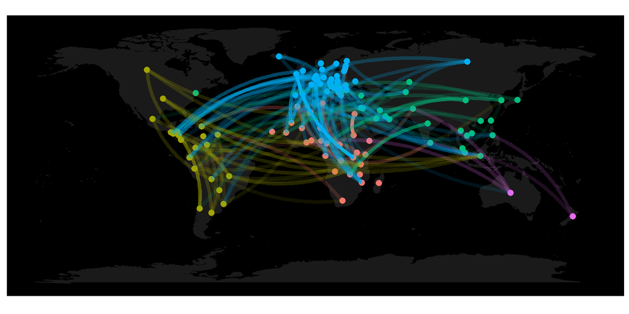

```r
library(ggplot2) # MAKE GRAPHICS

# create a layer of borders
worldmap <- borders("world", colour = "grey10", fill = "grey10")

# CREATE PLOT
ggplot() + worldmap +
  geom_point(data = coord_data,
             aes(x = lon, y = lat , col = continent), size = 3) +
  geom_curve(data = strong_ties,
             aes(x = lon.a, y = lat.a,
                 xend = lon.b, yend = lat.b,
                 alpha = weight,
                 col = continent.a),
             size = 2, curvature = .2) +
  scale_fill_brewer(palette = "Set3") +
  coord_fixed() +
  theme(
    panel.background = element_rect(fill = "black"),
    axis.line = element_blank(),
    axis.text.x = element_blank(),
    axis.text.y = element_blank(),
    axis.ticks = element_blank(),
    axis.title.x = element_blank(),
    axis.title.y = element_blank(),
    panel.grid.major = element_blank(),
    panel.grid.minor = element_blank(),
    legend.position = "none"
  )
```

# Assignment 5

1. Read the **Craft of Research, Chapter 16** (posted to BlackBoard in the Tips on Writing Folder)
2. Use the formula they prescribe to write an introduction for your final paper
3. You will be graded based on how convincing I find your argument:
   - how compelling is the problem you will address?
   - how well will your response address the problem?